# Diversity

Maria Dermit

2020-06-28

```r
library(tidyverse)
library(scales)
library(foreign) # this package allows reading of .sav files
library(wesanderson)
library(ggrepel)
library(pewmethods) #this package allows exploration of Pew Research Center survey data
library(emo) # for rainbows and unicorns
```

# Motivation to do this comparison

Given that we are in pride month 🌈, I came across this article, where it was really great to see increase trend for homosexuality, and not so great to see low accpetance in some regions.

[figure not shown]

I decided to use this great dataset to see by myself the trends towards diversity over the past two decades.

## Steps to do these analyses

### Data Collection

I got the data from [Pew Research Centre](https://www.pewresearch.org/global/datasets/)

### The question I want to explore is: how is diversity perceived across different countries

This is the question is located the survey dataset

```r
get_spss_label(dataset, 10)
```

```
## [1] "Q8. Do you think this is a good thing or a bad thing for (survey country)?"
```

```r
names(dataset)[10]
```

```
## [1] "diversity20yr_fu"
```

### Data visualization

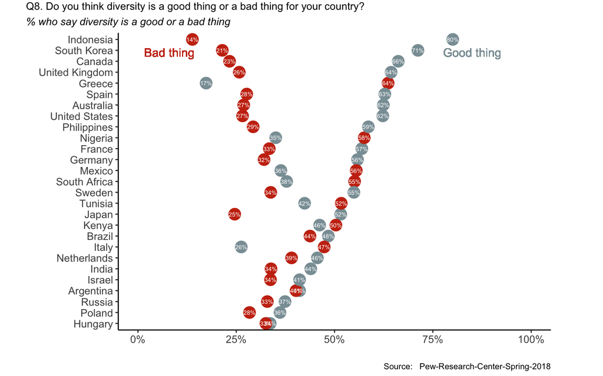

```r
dataset %>%
  select(diversity20yr_fu,COUNTRY) %>%
  group_by(COUNTRY,diversity20yr_fu) %>%
  tally  %>%
  group_by(COUNTRY) %>%
  mutate(pct=(100*n)/sum(n)) %>%
  filter(diversity20yr_fu %in% c("Good thing","Bad thing")) %>%
  ggplot(aes(pct,fct_reorder(COUNTRY,pct,.fun=max),label=paste0(round(pct, 0), "%"))) +
  geom_segment(aes( xend = pct, yend = COUNTRY)) +
  geom_point(aes(color = diversity20yr_fu),size = 5) +
  geom_text(color = "white", size = 2)+
  scale_color_manual(values = wes_palette("Royal1"))+
  scale_x_continuous(labels =function(l) {
    paste0(l,"%")}, limits=c(0,100)) +
  #geom_text(aes(label = diversity20yr_fu, size = 8, vjust =-1)) +
  geom_text(aes(x = 8, y = "Indonesia", label = "Bad thing"),
  color = wes_palette("Royal1")[2], size = 4, family = "", vjust = 2) +
  geom_text(aes(x = 85, y = "Indonesia", label = "Good thing"),
  color = wes_palette("Royal1")[1], size = 4, family = "", vjust = 2) +
  labs(title=gsub("this","diversity",gsub("\\(survey country\\)",
  "your country",get_spss_label(dataset, 10))), y="", x="",
  subtitle = "% who say diversity is a good or a bad thing",
  caption="Source:   Pew-Research-Center-Spring-2018") +
    theme_classic()+
  theme(
      legend.position = "none",
      plot.title=element_text(size=10, family=""),  # title
      plot.title.position = "plot",
      plot.subtitle = element_text(face = "italic", size = 10),
      plot.caption=element_text(size=8),  # caption
      #plot.caption.position = "plot",
      axis.title.x=element_text(size=10),  # X axis title
      axis.title.y=element_text(size=10),  # Y axis title
      axis.text.x=element_text(size=10),  # X axis text
      axis.text.y=element_text(size=10),
      plot.margin = margin(2,50,5,25))
```

## Conlusions

Interestingly, some countries consider diversity mostly as a bad thing (such as Greece and Nigeria).

In the survey, there are several factors analysed such as education, religion, income etc, and those factors are associated with some of the replies of this survey.